# NFE2L2 activitiy in pediatric NAFLD cohort

Christian H. Holland[^1]

21 August, 2020

# Library and sources

These libraries and sources are used in this analysis

```r
library(tidyverse)
library(readxl)
library(janitor)
library(edgeR)
library(dorothea)
library(biobroom)
library(here)
library(ggpubr)
library(viper)

source(here("src/utils.R"))
```

# Data processing

## Tidy meta data

Raw meta data are deposit are priori in the “data” folder. Here the meta information are transformed in an appropriate format. Two samples are excluded due to poor quality.

```r
# categorical features
cat_feats = read_excel(here("data/pediatric_nafld_cohort/RNA_Seq_Daten.xlsx"),
                    sheet = 1) %>%
  janitor::clean_names() %>%
  mutate(sample = str_c("I103", nr_dortmund_rna_seq + 22)) %>%
  select(-nr_dortmund_rna_seq) %>%
  select(sample, everything()) %>%
  mutate(
    gender = case_when(
      gender == 1 ~ "male",
      gender == 2 ~ "female"
    ),
    steatosis = str_c("grade_", steatosis),
    mild_vs_severe_steatosis = case_when(
      mild_vs_severe_steatosis == 0 ~ "grade_1",
      mild_vs_severe_steatosis == 1 ~ "grade_23"
    ),
    fibrosis = case_when(
      fibrosis == 0 ~ "no",
      fibrosis == 1 ~ "low",
      fibrosis == 2 ~ "mid",
      fibrosis == 3 ~ "high"
    ),
    mild_vs_advanced_fibrosis = case_when(
      mild_vs_advanced_fibrosis == 0 ~ "grade_1",
      mild_vs_advanced_fibrosis == 1 ~ "grade_23"
    ),
    inflammation_portal = case_when(
      inflammation_portal == 0 ~ "none",
      inflammation_portal == 1 ~ "mild",
      inflammation_portal == 2 ~ "severe"
    ),
    ballooning = case_when(
      ballooning == 0 ~ "none",
      ballooning == 1 ~ "few",
      ballooning == 2 ~ "prominent"
    )
  ) %>%
  mutate(
    gender = factor(gender, levels = c("male", "female")),
    steatosis = factor(steatosis, levels = c("grade_1", "grade_2", "grade_3")),
    mild_vs_severe_steatosis = factor(mild_vs_severe_steatosis, levels = c("grade_1", "grade_23")),
    fibrosis = factor(fibrosis, levels = c("no", "low", "mid", "high")),
    mild_vs_advanced_fibrosis = factor(mild_vs_advanced_fibrosis, levels = c("grade_1", "grade_23")),
    inflammation_portal = factor(inflammation_portal, levels = c("none", "mild", "severe")),
    ballooning = factor(ballooning, levels = c("none", "few", "prominent"))
  ) %>%
  mutate_if(is.double, as_factor)

# numerical features
num_feats = read_excel(here("data/pediatric_nafld_cohort/RNA_Seq_Daten.xlsx"),
                       sheet = 2, na = "x") %>%
  janitor::clean_names() %>%
  mutate(sample = str_c("I103", nr_dortmund_rna_seq + 22),
         age = as.integer(age)) %>%
  rename(weight = gewicht) %>%
  mutate(snp_gckr_rs1260326 = factor(snp_gckr_rs1260326, levels = c(0,1,2)),
         snp_gckr_rs780094 = factor(snp_gckr_rs780094, levels = c(0,1,2)),
         snp_ucp2_rs659366 = factor(snp_ucp2_rs659366, levels = c(0,1,2))) %>%
  select(-nr_dortmund_rna_seq, -x) %>%
  select(sample, everything())

excluded_samples = c("I10360","I10338") # low quality
meta = left_join(cat_feats, num_feats, by=c("sample", "study_id")) %>%
  arrange(sample) %>%
  filter(!sample %in% excluded_samples)

saveRDS(meta, here("output/pediatric_nafld_cohort/meta.rds"))

meta
```

| sample | study_id | gender | steatosis | mild_vs_severe_steatosis | fibrosis | mild_vs_advanced_fibrosis | inflammation_portal | inflammation_lobular | zonation | ballooning | snp_pnpla3_rs738409 | snp_pnpla3_rs2294918 | age | bmi_sds | bmi | weight | homa_ir | nu_insulin | nu_glucose | hff | snp_gckr_rs1260326 | snp_gckr_rs780094 | snp_ucp2_rs659366 |
| --- | --- | --- | --- | --- | --- | --- | --- | --- | --- | --- | --- | --- | --- | --- | --- | --- | --- | --- | --- | --- | --- | --- | --- |
| I10323 | 0116-56 | male | grade_2 | grade_23 | no | grade_1 | none | 0 | 3 | none | 0 | 0 | 16 | 2.80 | 35.2 | 116.5 | 4.7 | 23.81 | 79 | 35.00000 | 1 | 1 | 0 |
| I10324 | 0116-57 | male | grade_3 | grade_23 | low | grade_1 | mild | 1 | 4 | none | 1 | 2 | 13 | 1.90 | 26.7 | 61.6 | 3.1 | 14.49 | 87 | NA | 2 | 2 | 1 |
| I10325 | 0116-58 | male | grade_2 | grade_23 | mid | grade_23 | mild | 2 | 3 | prominent | 0 | 2 | 16 | 2.91 | 36.4 | 116.0 | 5.1 | 24.51 | 85 | 22.00000 | 2 | 2 | 2 |
| I10326 | 0116-59 | male | grade_1 | grade_1 | no | grade_1 | none | 0 | 0 | none | 0 | 2 | 17 | 2.96 | 36.7 | 129.7 | 8.3 | 37.72 | 89 | 6.00000 | 1 | 1 | 0 |
| I10327 | 0216-60 | male | grade_2 | grade_23 | low | grade_1 | mild | 1 | 3 | few | 0 | 1 | 14 | 2.80 | 35.3 | 106.4 | 13.6 | 64.23 | 86 | 31.00000 | 0 | 0 | 0 |
| I10328 | 0217-2 | female | grade_2 | grade_23 | no | grade_1 | mild | 0 | 3 | few | 0 | 0 | 13 | 2.80 | 33.6 | 94.5 | 7.1 | 35.64 | 81 | NA | 2 | 2 | 1 |
| I10329 | 0317-71 | male | grade_1 | grade_1 | high | grade_23 | mild | 1 | 3 | none | 1 | 1 | 13 | 3.10 | 39.9 | 127.7 | 13.4 | 58.45 | 93 | NA | 2 | 2 | 0 |
| I10330 | 0416-55 | male | grade_2 | grade_23 | no | grade_1 | none | 0 | 3 | none | 1 | 2 | 16 | 3.37 | 42.1 | 138.0 | 10.8 | 46.91 | 93 | NA | 1 | 1 | 1 |
| I10331 | 0416-61 | female | grade_3 | grade_23 | mid | grade_23 | none | 1 | 4 | few | 1 | 2 | 15 | 2.22 | 29.5 | 88.6 | 9.2 | 50.48 | 74 | 35.85195 | 1 | 1 | 1 |
| I10332 | 0416-62 | male | grade_3 | grade_23 | high | grade_23 | severe | 2 | 1 | none | 1 | 1 | 10 | 3.09 | 35.3 | 83.1 | 5.1 | NA | 77 | 36.58324 | 1 | 1 | 1 |

[output cut: 53 more lines]

## Process count matrix

The raw count matrix is also deposit a priori in the data folder. Also here the poor quality samples must be excluded.

```r
count_mat = read.delim(here("data/pediatric_nafld_cohort/raw_read_counts.txt"),
                       sep="\t", row.names = 1)

count_mat_qc = count_mat[, setdiff(colnames(count_mat), excluded_samples)]

saveRDS(count_mat_qc, here("output/pediatric_nafld_cohort/count_mat.rds"))
```

# Normalization

Count matrix is normalized via voom which filters for low read counts, performs a TMM normalization and transforms the values to logCPMs.

```r
meta = readRDS(here("output/pediatric_nafld_cohort/meta.rds"))
count_mat = readRDS(here("output/pediatric_nafld_cohort/count_mat.rds"))

# check if count and meta data and matrix correspond to each other
stopifnot(identical(colnames(count_mat), as.character(meta$sample)))

dge_obj = count_mat %>%
  DGEList(group = meta$mild_vs_advanced_fibrosis)

# filter low read counts, TMM normalization and logCPM transformation
norm_expr = voom_normalization(dge_obj)

saveRDS(norm_expr, here("output/pediatric_nafld_cohort/norm_expr.rds"))
```

# TF activity inference

TF activities are inferred via the dorothe package.

```r
norm_expr = readRDS(here("output/pediatric_nafld_cohort/norm_expr.rds"))
meta = readRDS(here("output/pediatric_nafld_cohort/meta.rds"))

tf_scores = run_viper(norm_expr, dorothea_hs,
                      options = list(nes = T, method = "scale", minsize = 4,
                                     eset.filter = F, verbose=F), tidy = T) %>%
  as_tibble()
```

## TF activity of NFE2L2

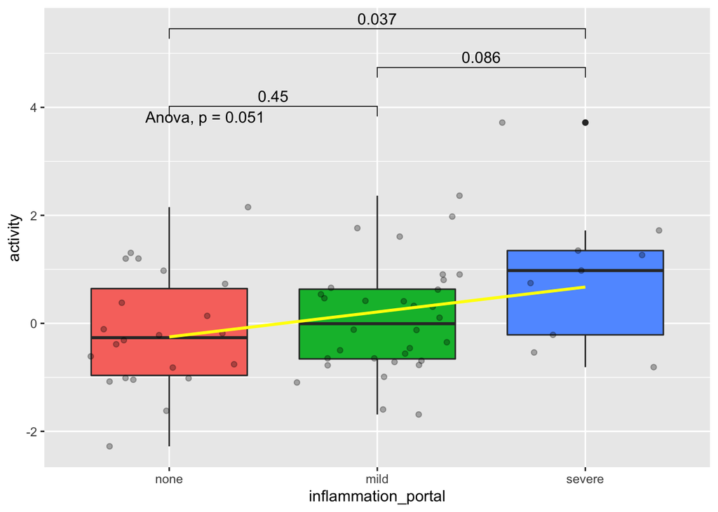

```r
a = tf_scores %>%
  left_join(meta, by="sample") %>%
  filter(tf %in% "NFE2L2")

a %>%
  ggplot(aes(x=inflammation_portal, y=activity, fill=inflammation_portal)) +
  geom_boxplot() +
  geom_jitter(alpha = 0.3) +
  theme(legend.position = "none") +
  ggpubr::stat_compare_means(method = "anova") +
  stat_compare_means(comparisons = list(c("none", "mild"), c("mild", "severe"),
                                        c("none", "severe"))) +
  geom_smooth(method = "lm", se = FALSE, color = "yellow", aes(group = 1))
```

```r
# anova
a %>%
  nest(data = -tf) %>%
  mutate(aov = data %>% map(~broom::tidy(
    aov(activity~inflammation_portal, data = .)))) %>%
  select(-data) %>%
  unnest(aov)
```

| tf | term | df | sumsq | meansq | statistic | p.value |
| --- | --- | --- | --- | --- | --- | --- |
| NFE2L2 | inflammation_portal | 2 | 7.351994 | 3.675997 | 3.135643 | 0.05067286 |
| NFE2L2 | Residuals | 60 | 70.339573 | 1.172326 | NA | NA |

```r
# anova post hoc test
a %>%
  nest(data = -tf) %>%
  mutate(tukey = data %>% map(~broom::tidy(
    TukeyHSD(aov(activity~inflammation_portal, data = .))))) %>%
  unnest(tukey) %>%
  select(-data, -null.value)
```

| tf | term | contrast | estimate | conf.low | conf.high | adj.p.value |
| --- | --- | --- | --- | --- | --- | --- |
| NFE2L2 | inflammation_portal | mild-none | 0.2294769 | -0.49117849 | 0.9501324 | 0.7256135 |
| NFE2L2 | inflammation_portal | severe-none | 1.0655250 | 0.03593251 | 2.0951175 | 0.0409412 |
| NFE2L2 | inflammation_portal | severe-mild | 0.8360481 | -0.14572882 | 1.8178250 | 0.1100043 |

```r
# linear models
a %>%
  nest(data = -tf) %>%
  mutate(lm = data %>% map(~broom::tidy(
    lm(activity~inflammation_portal, data = .)))) %>%
  unnest(lm) %>%
  filter(term != "(Intercept)") %>%
  select(-data)
```

| tf | term | estimate | std.error | statistic | p.value |
| --- | --- | --- | --- | --- | --- |
| NFE2L2 | inflammation_portalmild | 0.2294769 | 0.2998712 | 0.7652516 | 0.4471214 |
| NFE2L2 | inflammation_portalsevere | 1.0655250 | 0.4284227 | 2.4870880 | 0.0156778 |

```r
# correlations
a %>%
  mutate_if(is.factor, as.numeric) %>%
  nest(data = -tf) %>%
  mutate(r = data %>% map(~broom::tidy(
    cor.test(~activity + inflammation_portal, data = .,
             method = "spearman")))) %>%
  unnest(r) %>%
  select(-data)
```

| tf | estimate | statistic | p.value | method | alternative |
| --- | --- | --- | --- | --- | --- |
| NFE2L2 | 0.2430679 | 31536.82 | 0.05491426 | Spearman's rank correlation rho | two.sided |

## TF expression of NFE2L2

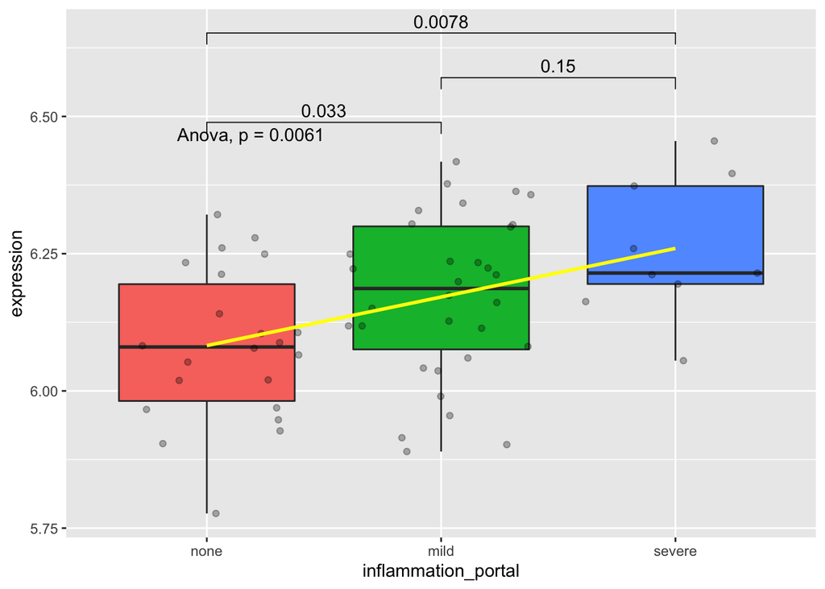

```r
e = norm_expr %>%
  tdy("gene", "sample", "expression") %>%
  left_join(meta, by="sample") %>%
  filter(gene %in% "NFE2L2")

e %>%
  ggplot(aes(x=inflammation_portal, y=expression, fill=inflammation_portal)) +
  geom_boxplot() +
  geom_jitter(alpha = 0.3) +
  theme(legend.position = "none") +
  stat_compare_means(comparisons = list(c("none", "mild"), c("mild", "severe"),
                                        c("none", "severe"))) +
  ggpubr::stat_compare_means(method = "anova") +
  geom_smooth(method = "lm", se = FALSE, color = "yellow", aes(group = 1))
```

```r
# anova
e %>%
  nest(data = -gene) %>%
  mutate(aov = data %>% map(~broom::tidy(
    aov(expression~inflammation_portal, data = .)))) %>%
  select(-data) %>%
  unnest(aov)
```

| gene | term | df | sumsq | meansq | statistic | p.value |
| --- | --- | --- | --- | --- | --- | --- |
| NFE2L2 | inflammation_portal | 2 | 0.2219354 | 0.1109677 | 5.557696 | 0.00610421 |
| NFE2L2 | Residuals | 60 | 1.1979899 | 0.0199665 | NA | NA |

```r
# anova post hoc test
e %>%
  nest(data = -gene) %>%
  mutate(tukey = data %>% map(~broom::tidy(
    TukeyHSD(aov(expression~inflammation_portal, data = .))))) %>%
  unnest(tukey) %>%
  select(-data, -null.value)
```

| gene | term | contrast | estimate | conf.low | conf.high | adj.p.value |
| --- | --- | --- | --- | --- | --- | --- |
| NFE2L2 | inflammation_portal | mild-none | 0.08998367 | -0.004065372 | 0.1840327 | 0.063568969 |
| NFE2L2 | inflammation_portal | severe-none | 0.17614664 | 0.041779809 | 0.3105135 | 0.007075092 |
| NFE2L2 | inflammation_portal | severe-mild | 0.08616297 | -0.041963692 | 0.2142896 | 0.246778115 |

```r
# linear models
e %>%
  nest(data = -gene) %>%
  mutate(lm = data %>% map(~broom::tidy(lm(expression~inflammation_portal,
                                           data = .)))) %>%
  unnest(lm) %>%
  filter(term != "(Intercept)") %>%
  select(-data)
```

| gene | term | estimate | std.error | statistic | p.value |
| --- | --- | --- | --- | --- | --- |
| NFE2L2 | inflammation_portalmild | 0.08998367 | 0.03913465 | 2.299335 | 0.024982507 |
| NFE2L2 | inflammation_portalsevere | 0.17614664 | 0.05591125 | 3.150469 | 0.002542347 |

```r
# correlation
e %>%
  mutate_if(is.factor, as.numeric) %>%
  nest(data = -gene) %>%
  mutate(r = data %>% map(~tidy(cor.test(~expression + inflammation_portal,
                                         data = ., method = "spearman")))) %>%
  unnest(r) %>%
  select(-data)
```

| gene | estimate | statistic | p.value | method | alternative |
| --- | --- | --- | --- | --- | --- |
| NFE2L2 | 0.3734217 | 26105.76 | 0.002574445 | Spearman's rank correlation rho | two.sided |

[^1]: Faculty of Medicine, Institute of Computational Biomedicine, Heidelberg University, Bioquant, Heidelberg, Germany, christian.holland@bioquant.uni-heidelberg.de